# Principal Component Analysis

Dataset intensidades_normalizadas_df

This dataset contains 8 individuals and 138746 variables, 1 qualitative variable is considered as illustrative.

### 1. Study of the outliers

The analysis of the graphs does not detect any outlier.

### 2. Inertia distribution

The inertia of the first dimensions shows if there are strong relationships between variables and suggests the number of dimensions that should be studied.

The first two dimensions of analyse express **39.95%** of the total dataset inertia ; that means that 39.95% of the individuals (or variables) cloud total variability is explained by the plane. This is an intermediate percentage and the first plane represents a part of the data variability. This value is greater than the reference value that equals **28.87%**, the variability explained by this plane is thus significant (the reference value is the 0.95-quantile of the inertia percentages distribution obtained by simulating 101 data tables of equivalent size on the basis of a normal distribution).

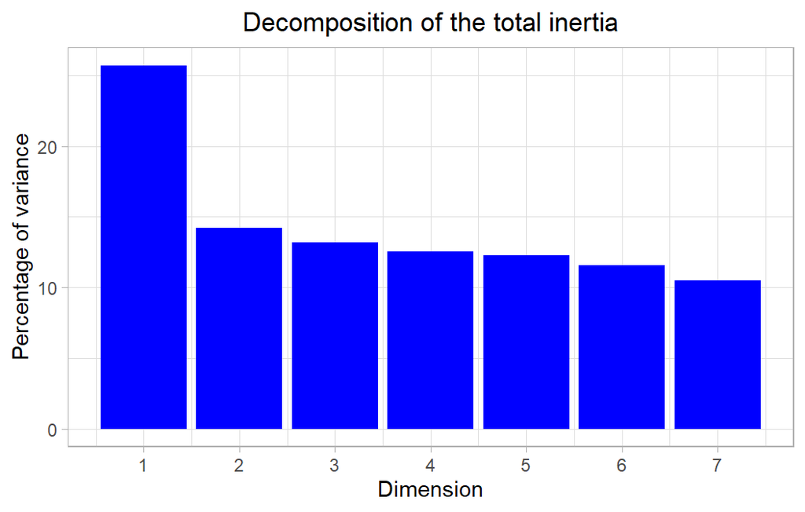

**Figure 2 - Decomposition of the total inertia**

An estimation of the right number of axis to interpret suggests to restrict the analysis to the description of the first 1 axis. These axis present an amount of inertia greater than those obtained by the 0.95-quantile of random distributions (25.73% against 14.47%). This observation suggests that only this axis is carrying a real information. As a consequence, the description will stand to these axis.